# STAT 240 Final Project

Salome Javakhishvili, Ryan Logan, Abhijay Movva, Faraz Behlum

### Introduction

The SAT is a multiple-choice, computer-based test. The purpose of the SAT is to measure a high school student’s capabilities in math and reading/writing, and is scored on a scale of 400 - 1600. It is usually taken a student’s junior year and the score is then submitted to colleges. The relationship between SAT scores and graduation rates in high schools is an area of interest for educators and policymakers alike. Some wonder if higher SAT scores correspond to better graduation rates, but what does the data reveal? In this analysis, we explored whether there is a linear relationship between SAT scores and graduation rates among New York City high schools.

By examining data from the 2012 graduation rates alongside 2012 SAT results provided by the NYC Department of Education, we found although there is a moderate positive correlation between the two, the average SAT scores and graduation rates do not have a linear relationship. Using a scatter plot, linear regression model, and residual plot, we hope to provide insights into how we came about our findings.

### Background

To answer our research question, we need data on average SAT scores within NYC schools in 2012 as well as graduation rates from the same high schools. Therefore, our dataset consists of data from two sources.

#### Graduation Data (2005-2019_Graduation_Rates_All.csv)

Our graduation data comes from the NYC Department of Education. This dataset catalogs the school names, year, the number of students within a cohort, graduation percent / number of graduated students, number of dropouts, number of students graduated students with honors, and more all from 2005 to 2019. The raw data contains thousands of rows for these various columns (reported graduation information for a school in a given year); however, for our purposes, we only collected rows corresponding to the year 2012, and only selected two columns: “School Name” and “% Grads”

The “School Name” column is simply a NYC school’s name; it allows us to filter the SAT data later so only the schools contained within both datasets will be shown within them. The “% Grads” column is a percentage of students who graduated within a school in a given year. It was already given in the original dataset but to be clear is a result of taking the values from the “# Grads” column and dividing them by the values from the “# Total Cohort” column for each row.

#### SAT Data (2012_SAT_Results.csv)

Our SAT data comes from the NYC Department of Education. The resulting dataset has four columns: one for the number of test takers, and then the rest for the average reading, writing, and math scores.

#### Combined Data

With these two datasets in hand, we can join them together on their respective school_name columns into one dataset, and then conduct some statistical analysis to see if the graduation rates within NYC schools change with average SAT scores.

### Statistical Analysis

#### Linear Regression Model

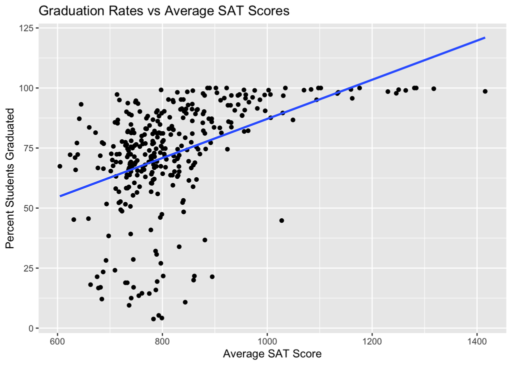

While this plot shows at the graduation rates having no linear relationship with average SAT scores, we need to conduct further analysis to say anything conclusively. We will do this with a residual model.

#### The Linear Model

A linear model allows us to examine the relationship between two variables, like average SAT and graduation rates, and determine if that relationship is statistically significant

```
##
## Call:
## lm(formula = percent_grad ~ avg_sat, data = dataset)
##
## Residuals:
##     Min      1Q  Median      3Q     Max
## -66.562  -6.706   4.146  12.478  34.988
##
## Coefficients:
##             Estimate Std. Error t value Pr(>|t|)
## (Intercept) 5.649648   7.298033   0.774    0.439
## avg_sat     0.081492   0.008786   9.275   <2e-16 ***
## ---
## Signif. codes:  0 '***' 0.001 '**' 0.01 '*' 0.05 '.' 0.1 ' ' 1
##
## Residual standard error: 19.83 on 333 degrees of freedom
## Multiple R-squared:  0.2053, Adjusted R-squared:  0.2029
## F-statistic: 86.02 on 1 and 333 DF,  p-value: < 2.2e-16
```

Using our model, we can generate a residual model and plot. This helps us visualize the differences between the observed data points and the values predicted by the linear model, allowing assessment of the model’s assumptions.

#### The Residual Model and Residual Plot

```
##    Min. 1st Qu.  Median    Mean 3rd Qu.    Max.
## -66.562  -6.706   4.146   0.000  12.478  34.988
```

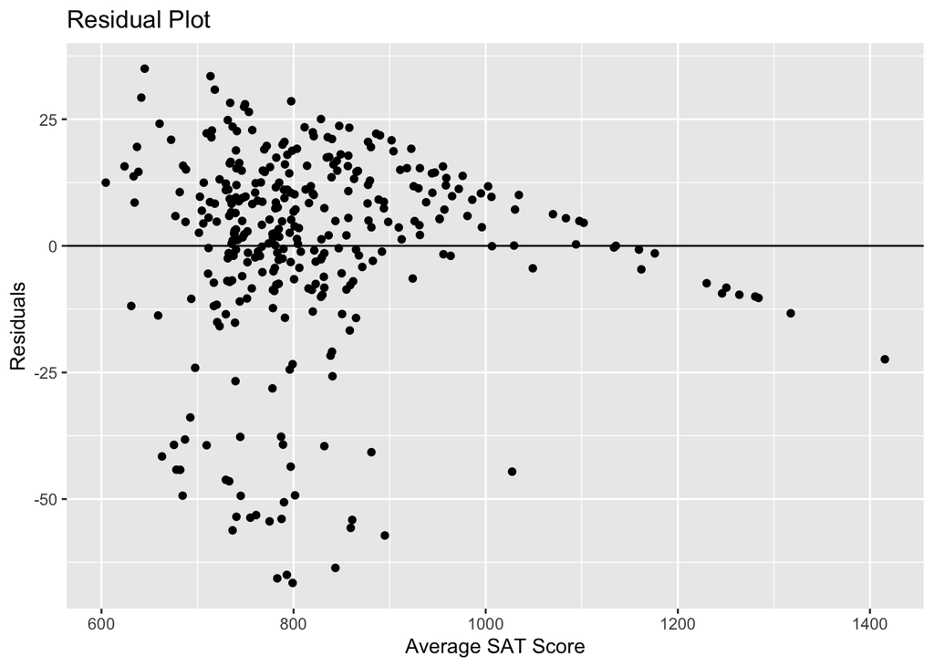

#### Checking Assumptions of our Linear Regression Model with our Residual Plot

1. Linearity: The residuals show an obvious non-linear pattern. Therefore, this assumption is violated.
2. Normal Errors Around 0 : The points don’t tend to be near the line on average, and the points aren’t evenly spread in both directions around 0. Therefore, this assumption is violated.
3. Constant Variance/SD: The spread of the residuals around the center line decreases or “funnels in” as you move horizontally across the plot. Therefore, this assumption is violated.

Although one violation is enough, we still checked all 3 and can see all were violated. Still, lets perform a hypothesis test for Beta-1, the slope of the linear relationship between the two variables in our linear regression model.

$$H_0: \beta_1 = 0 \quad \text{}\quad H_A:
\beta_1 > 0$$

Our p-value being extremely close to 0, suggests very strong evidence against our null hypothesis ($H_0: \beta_1 = 0$), therefore we must reject the null hypothesis. The slope is significantly different from zero.

The confidence interval (0.0587, 0.1043) indicates a statistically significant positive relationship between the variables at the 99% confidence level. The slope is unlikely to be zero, reinforcing the finding that the independent variable has a positive effect on the dependent variable.

### Discussion

The correlation coefficient between the average SAT scores and the graduation rates of the schools in NY is 0.453095 which implies that there is a moderate positive correlation but using our statistical models above we can see it is not linear. The strength of the correlation moderately strong, but not strong enough to imply a tightly bound relationship between SAT scores and the graduation rates of NY schools.

#### Further Interpretation

Since the correlation is not strong enough to imply a strong correlation there are probably other existing factors that effect both variables of average SAT scores and the graduation rates of the different NY highschools.

#### Short-comings and Future Work

One short-coming we had was that we assumed that the datasets we used would have a strong positive linear correlation. In reality, the data showed a moderate positive linear correlation which we weren’t expecting. We also thought we would conclude the two variables had a strong linear relationship, but this clearly wasn’t the case. Because of this our analysis of our question isn’t as strong as it could be since there is no solid correlation or linear relationship. This leads us to wonder what other factors influence the correlation between the average SAT scores and the graduation rates of NY high schools and what other factors other than SAT scores could possibly have a linear relationship with the graduation rates.

#### Conclusion

In conclusion, the analysis revealed a moderate positive correlation (0.453095) between average SAT scores and graduation rates in NY high schools, but our statistical models suggest that relationship is in fact not strongly linear. The findings highlight the likelihood of other influencing factors beyond these two variables. Future studies could explore additional variables to better understand the these outcomes and refine the initial assumptions about the strength and nature of the correlation.

### References

“2005-2019 Graduation Rates - All”: https://data.cityofnewyork.us/Education/2005-2019-Graduation-Rates-All/3vje-du8p/about_data

“2012 SAT Results”: https://data.cityofnewyork.us/Education/2012-SAT-Results/f9bf-2cp4/about_data

Used to find how to replace all instances of “s” within dataset to “NA”: https://cran.r-project.org/web/packages/naniar/vignettes/replace-with-na.html